# Risk Factor Analysis

## Outcome Variable

**Outcome Variable:** wasted

## Predictor Variables

**Intervention Variable:** pers_wast

**Adjustment Set:**

unadjusted

## Stratifying Variables

The analysis was stratified on these variable(s):

- agecat
- studyid
- country

## Data Summary

| agecat | studyid | country | pers_wast | wasted | n_cell | n |
| --- | --- | --- | --- | --- | --- | --- |
| Birth | ki0047075b-MAL-ED | BANGLADESH | 0 | 0 | 196 | 241 |
| Birth | ki0047075b-MAL-ED | BANGLADESH | 0 | 1 | 36 | 241 |
| Birth | ki0047075b-MAL-ED | BANGLADESH | 1 | 0 | 5 | 241 |
| Birth | ki0047075b-MAL-ED | BANGLADESH | 1 | 1 | 4 | 241 |
| Birth | ki0047075b-MAL-ED | BRAZIL | 0 | 0 | 177 | 183 |
| Birth | ki0047075b-MAL-ED | BRAZIL | 0 | 1 | 6 | 183 |
| Birth | ki0047075b-MAL-ED | BRAZIL | 1 | 0 | 0 | 183 |
| Birth | ki0047075b-MAL-ED | BRAZIL | 1 | 1 | 0 | 183 |
| Birth | ki0047075b-MAL-ED | INDIA | 0 | 0 | 165 | 203 |
| Birth | ki0047075b-MAL-ED | INDIA | 0 | 1 | 23 | 203 |
| Birth | ki0047075b-MAL-ED | INDIA | 1 | 0 | 5 | 203 |
| Birth | ki0047075b-MAL-ED | INDIA | 1 | 1 | 10 | 203 |
| Birth | ki0047075b-MAL-ED | NEPAL | 0 | 0 | 147 | 168 |
| Birth | ki0047075b-MAL-ED | NEPAL | 0 | 1 | 18 | 168 |
| Birth | ki0047075b-MAL-ED | NEPAL | 1 | 0 | 1 | 168 |
| Birth | ki0047075b-MAL-ED | NEPAL | 1 | 1 | 2 | 168 |
| Birth | ki0047075b-MAL-ED | PERU | 0 | 0 | 273 | 279 |
| Birth | ki0047075b-MAL-ED | PERU | 0 | 1 | 6 | 279 |
| Birth | ki0047075b-MAL-ED | PERU | 1 | 0 | 0 | 279 |
| Birth | ki0047075b-MAL-ED | PERU | 1 | 1 | 0 | 279 |
| Birth | ki0047075b-MAL-ED | SOUTH AFRICA | 0 | 0 | 239 | 258 |
| Birth | ki0047075b-MAL-ED | SOUTH AFRICA | 0 | 1 | 14 | 258 |
| Birth | ki0047075b-MAL-ED | SOUTH AFRICA | 1 | 0 | 1 | 258 |
| Birth | ki0047075b-MAL-ED | SOUTH AFRICA | 1 | 1 | 4 | 258 |
| Birth | ki0047075b-MAL-ED | TANZANIA, UNITED REPUBLIC OF | 0 | 0 | 116 | 118 |
| Birth | ki0047075b-MAL-ED | TANZANIA, UNITED REPUBLIC OF | 0 | 1 | 2 | 118 |
| Birth | ki0047075b-MAL-ED | TANZANIA, UNITED REPUBLIC OF | 1 | 0 | 0 | 118 |
| Birth | ki0047075b-MAL-ED | TANZANIA, UNITED REPUBLIC OF | 1 | 1 | 0 | 118 |
| Birth | ki1000108-CMC-V-BCS-2002 | INDIA | 0 | 0 | 68 | 88 |
| Birth | ki1000108-CMC-V-BCS-2002 | INDIA | 0 | 1 | 10 | 88 |

[output cut: 170 more lines]

The following strata were considered:

- agecat: 24 months, studyid: ki0047075b-MAL-ED, country: BANGLADESH
- agecat: 24 months, studyid: ki0047075b-MAL-ED, country: BRAZIL
- agecat: 24 months, studyid: ki0047075b-MAL-ED, country: INDIA
- agecat: 24 months, studyid: ki0047075b-MAL-ED, country: NEPAL
- agecat: 24 months, studyid: ki0047075b-MAL-ED, country: PERU
- agecat: 24 months, studyid: ki0047075b-MAL-ED, country: SOUTH AFRICA
- agecat: 24 months, studyid: ki0047075b-MAL-ED, country: TANZANIA, UNITED REPUBLIC OF
- agecat: 24 months, studyid: ki1000108-CMC-V-BCS-2002, country: INDIA
- agecat: 24 months, studyid: ki1000108-IRC, country: INDIA
- agecat: 24 months, studyid: ki1017093b-PROVIDE, country: BANGLADESH
- agecat: 24 months, studyid: ki1066203-TanzaniaChild2, country: TANZANIA, UNITED REPUBLIC OF
- agecat: 24 months, studyid: ki1101329-Keneba, country: GAMBIA
- agecat: 24 months, studyid: ki1113344-GMS-Nepal, country: NEPAL
- agecat: 24 months, studyid: ki1114097-CMIN, country: BANGLADESH
- agecat: 24 months, studyid: ki1114097-CMIN, country: PERU
- agecat: 24 months, studyid: ki1114097-CONTENT, country: PERU
- agecat: 6 months, studyid: ki0047075b-MAL-ED, country: BANGLADESH
- agecat: 6 months, studyid: ki0047075b-MAL-ED, country: BRAZIL
- agecat: 6 months, studyid: ki0047075b-MAL-ED, country: INDIA
- agecat: 6 months, studyid: ki0047075b-MAL-ED, country: NEPAL
- agecat: 6 months, studyid: ki0047075b-MAL-ED, country: PERU
- agecat: 6 months, studyid: ki0047075b-MAL-ED, country: SOUTH AFRICA
- agecat: 6 months, studyid: ki0047075b-MAL-ED, country: TANZANIA, UNITED REPUBLIC OF
- agecat: 6 months, studyid: ki1000108-CMC-V-BCS-2002, country: INDIA
- agecat: 6 months, studyid: ki1000108-IRC, country: INDIA
- agecat: 6 months, studyid: ki1000109-EE, country: PAKISTAN
- agecat: 6 months, studyid: ki1000109-ResPak, country: PAKISTAN
- agecat: 6 months, studyid: ki1017093b-PROVIDE, country: BANGLADESH
- agecat: 6 months, studyid: ki1066203-TanzaniaChild2, country: TANZANIA, UNITED REPUBLIC OF
- agecat: 6 months, studyid: ki1101329-Keneba, country: GAMBIA
- agecat: 6 months, studyid: ki1112895-Guatemala BSC, country: GUATEMALA
- agecat: 6 months, studyid: ki1113344-GMS-Nepal, country: NEPAL
- agecat: 6 months, studyid: ki1114097-CMIN, country: BANGLADESH
- agecat: 6 months, studyid: ki1114097-CMIN, country: PERU
- agecat: 6 months, studyid: ki1114097-CONTENT, country: PERU
- agecat: Birth, studyid: ki0047075b-MAL-ED, country: BANGLADESH
- agecat: Birth, studyid: ki0047075b-MAL-ED, country: BRAZIL
- agecat: Birth, studyid: ki0047075b-MAL-ED, country: INDIA
- agecat: Birth, studyid: ki0047075b-MAL-ED, country: NEPAL
- agecat: Birth, studyid: ki0047075b-MAL-ED, country: PERU
- agecat: Birth, studyid: ki0047075b-MAL-ED, country: SOUTH AFRICA
- agecat: Birth, studyid: ki0047075b-MAL-ED, country: TANZANIA, UNITED REPUBLIC OF
- agecat: Birth, studyid: ki1000108-CMC-V-BCS-2002, country: INDIA
- agecat: Birth, studyid: ki1000108-IRC, country: INDIA
- agecat: Birth, studyid: ki1000109-EE, country: PAKISTAN
- agecat: Birth, studyid: ki1000109-ResPak, country: PAKISTAN
- agecat: Birth, studyid: ki1101329-Keneba, country: GAMBIA
- agecat: Birth, studyid: ki1114097-CMIN, country: BANGLADESH
- agecat: Birth, studyid: ki1114097-CMIN, country: PERU
- agecat: Birth, studyid: ki1114097-CONTENT, country: PERU

### Dropped Strata

Some strata were dropped due to rare outcomes:

- agecat: Birth, studyid: ki0047075b-MAL-ED, country: BANGLADESH
- agecat: Birth, studyid: ki0047075b-MAL-ED, country: BRAZIL
- agecat: Birth, studyid: ki0047075b-MAL-ED, country: NEPAL
- agecat: Birth, studyid: ki0047075b-MAL-ED, country: PERU
- agecat: Birth, studyid: ki0047075b-MAL-ED, country: SOUTH AFRICA
- agecat: Birth, studyid: ki0047075b-MAL-ED, country: TANZANIA, UNITED REPUBLIC OF
- agecat: Birth, studyid: ki1000108-CMC-V-BCS-2002, country: INDIA
- agecat: Birth, studyid: ki1000109-EE, country: PAKISTAN
- agecat: Birth, studyid: ki1000109-ResPak, country: PAKISTAN
- agecat: Birth, studyid: ki1114097-CMIN, country: BANGLADESH
- agecat: Birth, studyid: ki1114097-CMIN, country: PERU
- agecat: Birth, studyid: ki1114097-CONTENT, country: PERU
- agecat: 6 months, studyid: ki0047075b-MAL-ED, country: BANGLADESH
- agecat: 6 months, studyid: ki0047075b-MAL-ED, country: BRAZIL
- agecat: 6 months, studyid: ki0047075b-MAL-ED, country: NEPAL
- agecat: 6 months, studyid: ki0047075b-MAL-ED, country: PERU
- agecat: 6 months, studyid: ki0047075b-MAL-ED, country: SOUTH AFRICA
- agecat: 6 months, studyid: ki0047075b-MAL-ED, country: TANZANIA, UNITED REPUBLIC OF
- agecat: 6 months, studyid: ki1017093b-PROVIDE, country: BANGLADESH
- agecat: 6 months, studyid: ki1112895-Guatemala BSC, country: GUATEMALA
- agecat: 6 months, studyid: ki1114097-CMIN, country: BANGLADESH
- agecat: 6 months, studyid: ki1114097-CMIN, country: PERU
- agecat: 6 months, studyid: ki1114097-CONTENT, country: PERU
- agecat: 24 months, studyid: ki0047075b-MAL-ED, country: BANGLADESH
- agecat: 24 months, studyid: ki0047075b-MAL-ED, country: BRAZIL
- agecat: 24 months, studyid: ki0047075b-MAL-ED, country: NEPAL
- agecat: 24 months, studyid: ki0047075b-MAL-ED, country: PERU
- agecat: 24 months, studyid: ki0047075b-MAL-ED, country: SOUTH AFRICA
- agecat: 24 months, studyid: ki0047075b-MAL-ED, country: TANZANIA, UNITED REPUBLIC OF
- agecat: 24 months, studyid: ki1066203-TanzaniaChild2, country: TANZANIA, UNITED REPUBLIC OF
- agecat: 24 months, studyid: ki1114097-CMIN, country: BANGLADESH
- agecat: 24 months, studyid: ki1114097-CMIN, country: PERU
- agecat: 24 months, studyid: ki1114097-CONTENT, country: PERU

## Methods Detail

We’re interested in the causal parameters $E[Y_a]$ for all values of $a \in \mathcal{A}$. These parameters represent the mean outcome if, possibly contrary to fact, we intervened to set all units to have $A=a$. Under the randomization and positivity assumptions, these are identified by the statistical parameters $\psi_a=E_W[E_{Y|A,W}(Y|A=a,W)]$. In addition, we’re interested in the mean of $Y$, $E[Y]$ under no intervention (the observed mean). We will estimate these parameters by using SuperLearner to fit the relevant likelihood factors – $E_{Y|A,W}(Y|A=a,W)$ and $p(A=a|W)$, and then updating our likelihood fit using a joint TMLE.

For unadjusted analyses ($W=\{\}$), initial likelihoods were estimated using Lrnr_glm to estimate the simple $E(Y|A)$ and Lrnr_mean to estimate $p(A)$. For adjusted analyses, a small library containing Lrnr_glmnet, Lrnr_xgboost, and Lrnr_mean was used.

Having estimated these parameters, we will then use the delta method to estimate relative risks and attributable risks relative to a prespecified baseline level of $A$.

# Results Detail

## Results Plots

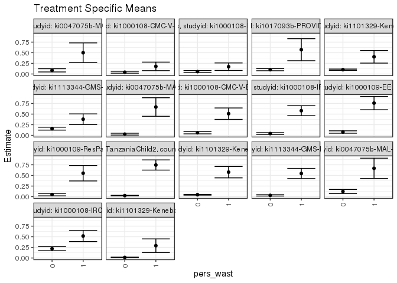

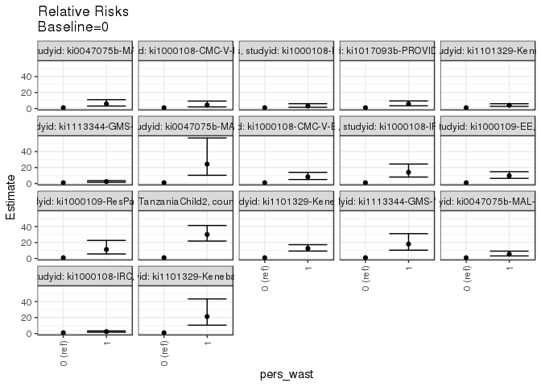

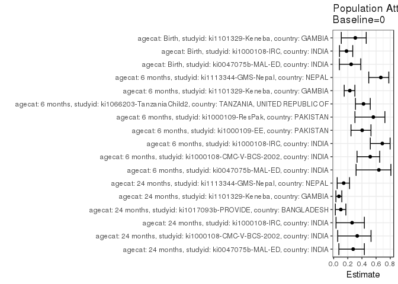

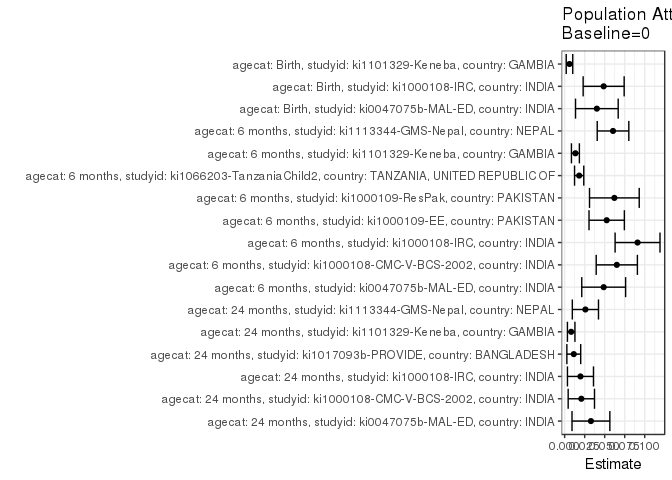

## Results Table

### Parameter: TSM

| agecat | studyid | country | intervention_level | baseline_level | estimate | ci_lower | ci_upper |
| --- | --- | --- | --- | --- | --- | --- | --- |
| Birth | ki0047075b-MAL-ED | INDIA | 0 | NA | 0.1223404 | 0.0753846 | 0.1692963 |
| Birth | ki0047075b-MAL-ED | INDIA | 1 | NA | 0.6666667 | 0.4275177 | 0.9058156 |
| Birth | ki1000108-IRC | INDIA | 0 | NA | 0.2195122 | 0.1715550 | 0.2674694 |
| Birth | ki1000108-IRC | INDIA | 1 | NA | 0.5178571 | 0.3867939 | 0.6489204 |
| Birth | ki1101329-Keneba | GAMBIA | 0 | NA | 0.0136494 | 0.0075519 | 0.0197470 |
| Birth | ki1101329-Keneba | GAMBIA | 1 | NA | 0.2903226 | 0.1304806 | 0.4501645 |
| 6 months | ki0047075b-MAL-ED | INDIA | 0 | NA | 0.0275229 | 0.0057594 | 0.0492864 |
| 6 months | ki0047075b-MAL-ED | INDIA | 1 | NA | 0.6666667 | 0.4484300 | 0.8849033 |
| 6 months | ki1000108-CMC-V-BCS-2002 | INDIA | 0 | NA | 0.0608974 | 0.0343255 | 0.0874693 |
| 6 months | ki1000108-CMC-V-BCS-2002 | INDIA | 1 | NA | 0.5094340 | 0.3746623 | 0.6442056 |
| 6 months | ki1000108-IRC | INDIA | 0 | NA | 0.0412979 | 0.0200906 | 0.0625053 |
| 6 months | ki1000108-IRC | INDIA | 1 | NA | 0.5797101 | 0.4631000 | 0.6963203 |
| 6 months | ki1000109-EE | PAKISTAN | 0 | NA | 0.0778098 | 0.0495877 | 0.1060319 |
| 6 months | ki1000109-EE | PAKISTAN | 1 | NA | 0.7586207 | 0.6026691 | 0.9145723 |
| 6 months | ki1000109-ResPak | PAKISTAN | 0 | NA | 0.0485437 | 0.0191333 | 0.0779541 |
| 6 months | ki1000109-ResPak | PAKISTAN | 1 | NA | 0.5517241 | 0.3703360 | 0.7331122 |
| 6 months | ki1066203-TanzaniaChild2 | TANZANIA, UNITED REPUBLIC OF | 0 | NA | 0.0247850 | 0.0179302 | 0.0316399 |
| 6 months | ki1066203-TanzaniaChild2 | TANZANIA, UNITED REPUBLIC OF | 1 | NA | 0.7450980 | 0.6254616 | 0.8647345 |
| 6 months | ki1101329-Keneba | GAMBIA | 0 | NA | 0.0453865 | 0.0362733 | 0.0544998 |
| 6 months | ki1101329-Keneba | GAMBIA | 1 | NA | 0.5769231 | 0.4426093 | 0.7112369 |
| 6 months | ki1113344-GMS-Nepal | NEPAL | 0 | NA | 0.0301811 | 0.0151265 | 0.0452357 |
| 6 months | ki1113344-GMS-Nepal | NEPAL | 1 | NA | 0.5454545 | 0.4252198 | 0.6656893 |
| 24 months | ki0047075b-MAL-ED | INDIA | 0 | NA | 0.0861244 | 0.0480055 | 0.1242433 |
| 24 months | ki0047075b-MAL-ED | INDIA | 1 | NA | 0.5000000 | 0.2685056 | 0.7314944 |
| 24 months | ki1000108-CMC-V-BCS-2002 | INDIA | 0 | NA | 0.0416667 | 0.0194635 | 0.0638698 |
| 24 months | ki1000108-CMC-V-BCS-2002 | INDIA | 1 | NA | 0.1785714 | 0.0781247 | 0.2790182 |
| 24 months | ki1000108-IRC | INDIA | 0 | NA | 0.0560472 | 0.0315322 | 0.0805622 |
| 24 months | ki1000108-IRC | INDIA | 1 | NA | 0.1714286 | 0.0830316 | 0.2598255 |
| 24 months | ki1017093b-PROVIDE | BANGLADESH | 0 | NA | 0.1010638 | 0.0761668 | 0.1259608 |
| 24 months | ki1017093b-PROVIDE | BANGLADESH | 1 | NA | 0.5714286 | 0.3119792 | 0.8308780 |
| 24 months | ki1101329-Keneba | GAMBIA | 0 | NA | 0.1011162 | 0.0859702 | 0.1162623 |
| 24 months | ki1101329-Keneba | GAMBIA | 1 | NA | 0.4047619 | 0.2562684 | 0.5532554 |
| 24 months | ki1113344-GMS-Nepal | NEPAL | 0 | NA | 0.1568182 | 0.1228074 | 0.1908290 |
| 24 months | ki1113344-GMS-Nepal | NEPAL | 1 | NA | 0.3793103 | 0.2543117 | 0.5043090 |

### Parameter: E(Y)

| agecat | studyid | country | intervention_level | baseline_level | estimate | ci_lower | ci_upper |
| --- | --- | --- | --- | --- | --- | --- | --- |
| Birth | ki0047075b-MAL-ED | INDIA | NA | NA | 0.1625616 | 0.1116803 | 0.2134428 |
| Birth | ki1000108-IRC | INDIA | NA | NA | 0.2682216 | 0.2212677 | 0.3151755 |
| Birth | ki1101329-Keneba | GAMBIA | NA | NA | 0.0196767 | 0.0124580 | 0.0268954 |
| 6 months | ki0047075b-MAL-ED | INDIA | NA | NA | 0.0762712 | 0.0423347 | 0.1102077 |
| 6 months | ki1000108-CMC-V-BCS-2002 | INDIA | NA | NA | 0.1260274 | 0.0919333 | 0.1601215 |
| 6 months | ki1000108-IRC | INDIA | NA | NA | 0.1323529 | 0.0994307 | 0.1652752 |
| 6 months | ki1000109-EE | PAKISTAN | NA | NA | 0.1303191 | 0.0962457 | 0.1643926 |
| 6 months | ki1000109-ResPak | PAKISTAN | NA | NA | 0.1106383 | 0.0704470 | 0.1508296 |
| 6 months | ki1066203-TanzaniaChild2 | TANZANIA, UNITED REPUBLIC OF | NA | NA | 0.0428994 | 0.0340782 | 0.0517206 |
| 6 months | ki1101329-Keneba | GAMBIA | NA | NA | 0.0588235 | 0.0486529 | 0.0689942 |
| 6 months | ki1113344-GMS-Nepal | NEPAL | NA | NA | 0.0905861 | 0.0668565 | 0.1143158 |
| 24 months | ki0047075b-MAL-ED | INDIA | NA | NA | 0.1189427 | 0.0767376 | 0.1611478 |
| 24 months | ki1000108-CMC-V-BCS-2002 | INDIA | NA | NA | 0.0625000 | 0.0377349 | 0.0872651 |
| 24 months | ki1000108-IRC | INDIA | NA | NA | 0.0757946 | 0.0501131 | 0.1014762 |
| 24 months | ki1017093b-PROVIDE | BANGLADESH | NA | NA | 0.1124567 | 0.0866788 | 0.1382347 |
| 24 months | ki1101329-Keneba | GAMBIA | NA | NA | 0.1092652 | 0.0938039 | 0.1247264 |
| 24 months | ki1113344-GMS-Nepal | NEPAL | NA | NA | 0.1827309 | 0.1487560 | 0.2167058 |

### Parameter: RR

| agecat | studyid | country | intervention_level | baseline_level | estimate | ci_lower | ci_upper |
| --- | --- | --- | --- | --- | --- | --- | --- |
| Birth | ki0047075b-MAL-ED | INDIA | 0 | 0 | 1.000000 | 1.000000 | 1.000000 |
| Birth | ki0047075b-MAL-ED | INDIA | 1 | 0 | 5.449275 | 3.222413 | 9.215020 |
| Birth | ki1000108-IRC | INDIA | 0 | 0 | 1.000000 | 1.000000 | 1.000000 |
| Birth | ki1000108-IRC | INDIA | 1 | 0 | 2.359127 | 1.688688 | 3.295743 |
| Birth | ki1101329-Keneba | GAMBIA | 0 | 0 | 1.000000 | 1.000000 | 1.000000 |
| Birth | ki1101329-Keneba | GAMBIA | 1 | 0 | 21.269949 | 10.467670 | 43.219813 |
| 6 months | ki0047075b-MAL-ED | INDIA | 0 | 0 | 1.000000 | 1.000000 | 1.000000 |
| 6 months | ki0047075b-MAL-ED | INDIA | 1 | 0 | 24.222222 | 10.292833 | 57.002389 |
| 6 months | ki1000108-CMC-V-BCS-2002 | INDIA | 0 | 0 | 1.000000 | 1.000000 | 1.000000 |
| 6 months | ki1000108-CMC-V-BCS-2002 | INDIA | 1 | 0 | 8.365442 | 5.022038 | 13.934706 |
| 6 months | ki1000108-IRC | INDIA | 0 | 0 | 1.000000 | 1.000000 | 1.000000 |
| 6 months | ki1000108-IRC | INDIA | 1 | 0 | 14.037267 | 8.086552 | 24.366980 |
| 6 months | ki1000109-EE | PAKISTAN | 0 | 0 | 1.000000 | 1.000000 | 1.000000 |
| 6 months | ki1000109-EE | PAKISTAN | 1 | 0 | 9.749681 | 6.425808 | 14.792890 |
| 6 months | ki1000109-ResPak | PAKISTAN | 0 | 0 | 1.000000 | 1.000000 | 1.000000 |
| 6 months | ki1000109-ResPak | PAKISTAN | 1 | 0 | 11.365517 | 5.704612 | 22.643957 |
| 6 months | ki1066203-TanzaniaChild2 | TANZANIA, UNITED REPUBLIC OF | 0 | 0 | 1.000000 | 1.000000 | 1.000000 |
| 6 months | ki1066203-TanzaniaChild2 | TANZANIA, UNITED REPUBLIC OF | 1 | 0 | 30.062425 | 21.834142 | 41.391568 |
| 6 months | ki1101329-Keneba | GAMBIA | 0 | 0 | 1.000000 | 1.000000 | 1.000000 |
| 6 months | ki1101329-Keneba | GAMBIA | 1 | 0 | 12.711327 | 9.346998 | 17.286601 |
| 6 months | ki1113344-GMS-Nepal | NEPAL | 0 | 0 | 1.000000 | 1.000000 | 1.000000 |
| 6 months | ki1113344-GMS-Nepal | NEPAL | 1 | 0 | 18.072727 | 10.475724 | 31.179083 |
| 24 months | ki0047075b-MAL-ED | INDIA | 0 | 0 | 1.000000 | 1.000000 | 1.000000 |
| 24 months | ki0047075b-MAL-ED | INDIA | 1 | 0 | 5.805556 | 3.059658 | 11.015766 |
| 24 months | ki1000108-CMC-V-BCS-2002 | INDIA | 0 | 0 | 1.000000 | 1.000000 | 1.000000 |
| 24 months | ki1000108-CMC-V-BCS-2002 | INDIA | 1 | 0 | 4.285714 | 1.974777 | 9.300973 |
| 24 months | ki1000108-IRC | INDIA | 0 | 0 | 1.000000 | 1.000000 | 1.000000 |
| 24 months | ki1000108-IRC | INDIA | 1 | 0 | 3.058647 | 1.555502 | 6.014342 |
| 24 months | ki1017093b-PROVIDE | BANGLADESH | 0 | 0 | 1.000000 | 1.000000 | 1.000000 |
| 24 months | ki1017093b-PROVIDE | BANGLADESH | 1 | 0 | 5.654135 | 3.373074 | 9.477778 |
| 24 months | ki1101329-Keneba | GAMBIA | 0 | 0 | 1.000000 | 1.000000 | 1.000000 |
| 24 months | ki1101329-Keneba | GAMBIA | 1 | 0 | 4.002937 | 2.693285 | 5.949429 |
| 24 months | ki1113344-GMS-Nepal | NEPAL | 0 | 0 | 1.000000 | 1.000000 | 1.000000 |
| 24 months | ki1113344-GMS-Nepal | NEPAL | 1 | 0 | 2.418791 | 1.630296 | 3.588641 |

### Parameter: PAR

| agecat | studyid | country | intervention_level | baseline_level | estimate | ci_lower | ci_upper |
| --- | --- | --- | --- | --- | --- | --- | --- |
| Birth | ki0047075b-MAL-ED | INDIA | 0 | NA | 0.0402212 | 0.0135774 | 0.0668649 |
| Birth | ki1000108-IRC | INDIA | 0 | NA | 0.0487094 | 0.0231015 | 0.0743173 |
| Birth | ki1101329-Keneba | GAMBIA | 0 | NA | 0.0060273 | 0.0019592 | 0.0100955 |
| 6 months | ki0047075b-MAL-ED | INDIA | 0 | NA | 0.0487483 | 0.0213569 | 0.0761396 |
| 6 months | ki1000108-CMC-V-BCS-2002 | INDIA | 0 | NA | 0.0651300 | 0.0394125 | 0.0908474 |
| 6 months | ki1000108-IRC | INDIA | 0 | NA | 0.0910550 | 0.0630150 | 0.1190950 |
| 6 months | ki1000109-EE | PAKISTAN | 0 | NA | 0.0525094 | 0.0304327 | 0.0745860 |
| 6 months | ki1000109-ResPak | PAKISTAN | 0 | NA | 0.0620946 | 0.0310487 | 0.0931406 |
| 6 months | ki1066203-TanzaniaChild2 | TANZANIA, UNITED REPUBLIC OF | 0 | NA | 0.0181144 | 0.0123535 | 0.0238752 |
| 6 months | ki1101329-Keneba | GAMBIA | 0 | NA | 0.0134370 | 0.0084783 | 0.0183957 |
| 6 months | ki1113344-GMS-Nepal | NEPAL | 0 | NA | 0.0604051 | 0.0406669 | 0.0801432 |
| 24 months | ki0047075b-MAL-ED | INDIA | 0 | NA | 0.0328183 | 0.0091823 | 0.0564543 |
| 24 months | ki1000108-CMC-V-BCS-2002 | INDIA | 0 | NA | 0.0208333 | 0.0043904 | 0.0372763 |
| 24 months | ki1000108-IRC | INDIA | 0 | NA | 0.0197474 | 0.0034909 | 0.0360039 |
| 24 months | ki1017093b-PROVIDE | BANGLADESH | 0 | NA | 0.0113929 | 0.0027518 | 0.0200340 |
| 24 months | ki1101329-Keneba | GAMBIA | 0 | NA | 0.0081490 | 0.0034627 | 0.0128352 |
| 24 months | ki1113344-GMS-Nepal | NEPAL | 0 | NA | 0.0259127 | 0.0095726 | 0.0422529 |

### Parameter: PAF

| agecat | studyid | country | intervention_level | baseline_level | estimate | ci_lower | ci_upper |
| --- | --- | --- | --- | --- | --- | --- | --- |
| Birth | ki0047075b-MAL-ED | INDIA | 0 | NA | 0.2474210 | 0.0809477 | 0.3837401 |
| Birth | ki1000108-IRC | INDIA | 0 | NA | 0.1816013 | 0.0827398 | 0.2698075 |
| Birth | ki1101329-Keneba | GAMBIA | 0 | NA | 0.3063167 | 0.1078400 | 0.4606388 |
| 6 months | ki0047075b-MAL-ED | INDIA | 0 | NA | 0.6391437 | 0.3173553 | 0.8092459 |
| 6 months | ki1000108-CMC-V-BCS-2002 | INDIA | 0 | NA | 0.5167921 | 0.3305343 | 0.6512295 |
| 6 months | ki1000108-IRC | INDIA | 0 | NA | 0.6879712 | 0.5181385 | 0.7979461 |
| 6 months | ki1000109-EE | PAKISTAN | 0 | NA | 0.4029289 | 0.2452208 | 0.5276845 |
| 6 months | ki1000109-ResPak | PAKISTAN | 0 | NA | 0.5612397 | 0.3011537 | 0.7245309 |
| 6 months | ki1066203-TanzaniaChild2 | TANZANIA, UNITED REPUBLIC OF | 0 | NA | 0.4222525 | 0.3079077 | 0.5177056 |
| 6 months | ki1101329-Keneba | GAMBIA | 0 | NA | 0.2284289 | 0.1491367 | 0.3003319 |
| 6 months | ki1113344-GMS-Nepal | NEPAL | 0 | NA | 0.6668245 | 0.4961500 | 0.7796846 |
| 24 months | ki0047075b-MAL-ED | INDIA | 0 | NA | 0.2759171 | 0.0737954 | 0.4339306 |
| 24 months | ki1000108-CMC-V-BCS-2002 | INDIA | 0 | NA | 0.3333333 | 0.0573857 | 0.5284981 |
| 24 months | ki1000108-IRC | INDIA | 0 | NA | 0.2605386 | 0.0336615 | 0.4341495 |
| 24 months | ki1017093b-PROVIDE | BANGLADESH | 0 | NA | 0.1013093 | 0.0240909 | 0.1724179 |
| 24 months | ki1101329-Keneba | GAMBIA | 0 | NA | 0.0745796 | 0.0317447 | 0.1155196 |
| 24 months | ki1113344-GMS-Nepal | NEPAL | 0 | NA | 0.1418082 | 0.0502526 | 0.2245378 |